# Descriptive Statistics

Please go to Session on the RStudio Menu, and click on ‘Restart R and Clear Output’.

Tutorial adapted from: https://rafalab.github.io/dsbook/

# DISTRIBUTIONS

Here we demonstrate how to generate plots related to distributions.

Load the **tidyverse** libraries. And load the murders dataset from the **dslabs** package.

```r
library(tidyverse)
library(dslabs)
data(murders)
```

## Barplots

To generate a barplot we can use the `geom_bar` geometry. The default is to count the number of each category and draw a bar. Here is the plot for the regions of the US.

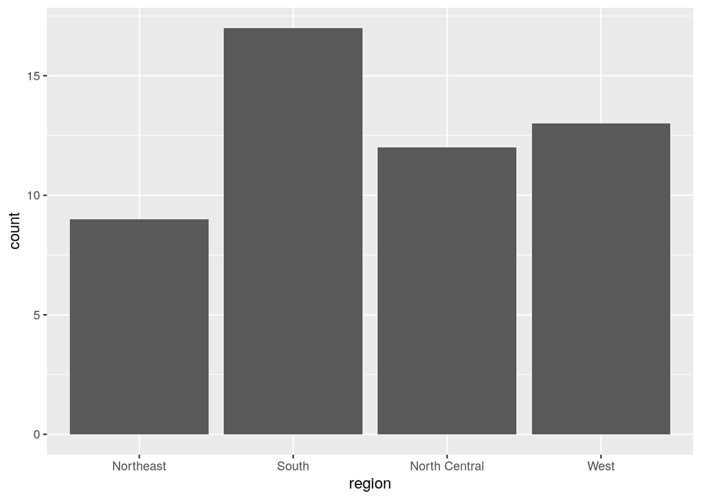

```r
murders %>% ggplot(aes(region)) + geom_bar()
```

We often already have a table with a distribution that we want to present as a barplot. Here is an example of such a table:

```r
tab <- murders %>%
  count(region) %>%
  mutate(proportion = n/sum(n))
tab
```

```
##          region  n proportion
## 1     Northeast  9  0.1764706
## 2         South 17  0.3333333
## 3 North Central 12  0.2352941
## 4          West 13  0.2549020
```

We no longer want `geom_bar` to count, but rather just plot a bar to the height provided by the `proportion` variable. For this we need to provide `x` (the categories) and `y` (the values) and use the `stat="identity"` option.

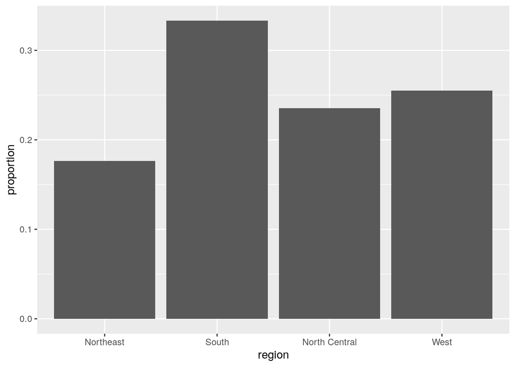

```r
tab %>% ggplot(aes(region, proportion)) + geom_bar(stat = "identity")
```